#### **To: Manager at Under Armour**

#### **From: David Deans**

#### **Date: June 13, 2019**

#### **Insight into the Survey put out to Athletic Apparel purchasing Women**

# Introduction

In order to enter the female athletic apparel space, Under Armour must understand the people we are hoping to entice our products with. To reach this goal, we took a survey of performance apparel products and asked them an array of questions. With this information, we will be able to determine what general athletic consumers are interested in, as well as what current Under Armour consumers value us for. We have a few different ways of measuring this data to determine targetable segments of the market. The survey data goes through a large listing of stances consumers either agree or disagree with on a 7 point Likert scale. Among these are questions of Under Armour’s brand image, the importance of environmentalism, women’s issues, corporate social responsibility, and product importance. Participants were asked various questions on the importance of their product’s value, aesthetic, performance benefit, as well as the importance of their own level of knowledge on the subject. We will be comparing our survey data to age group and income primarily.

# Insight 1: Survey participants were most likely to be swayed by Peer Opinion, Family Opinion, and Sales on Items

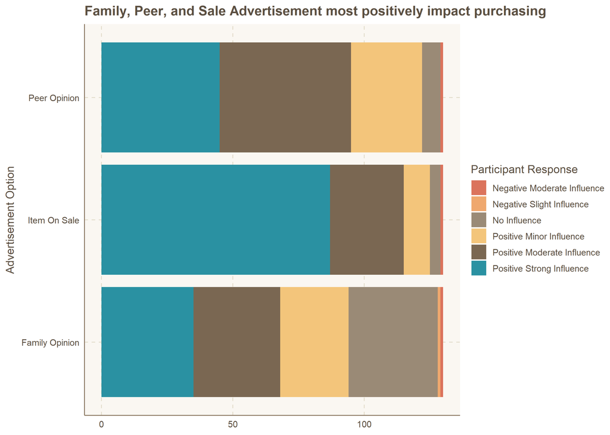

The goal of our survey is to better understand our potential consumers, and understanding our communication points with these people is a cornerstone to our goals. Through studying the participant responses, it has been determined that Under Armour will benefit from focusing on promoting thier Peer Opinion, Family Opinion, and Promotional Sale marketing. Our horizontal axis is a simple count from the participants in this graph which includes all participants with valid survey data. The vertical axis shows our three advertisement options: Peer Opinion, Item On Sale, and Family Opinion. The bars for each of these advertisement options are broken down by the overral participant response to each idea. From Orange to Blue (or top to bottom on the legend), the colors represent Negative Opinion to Positive, with light brown being our neutral point. As the graph shows, a staggeringly high amount of participants found these three advertisement forms positively influential to their purchasing decisions, especially putting an item on sale. While it may be difficult to produce peer and family marketing, it may be possible through using sales to put Under Armour products in the hands of more people.

# Insight 2: There are more 18-24 year old Under Armour consumers than every other age group combined

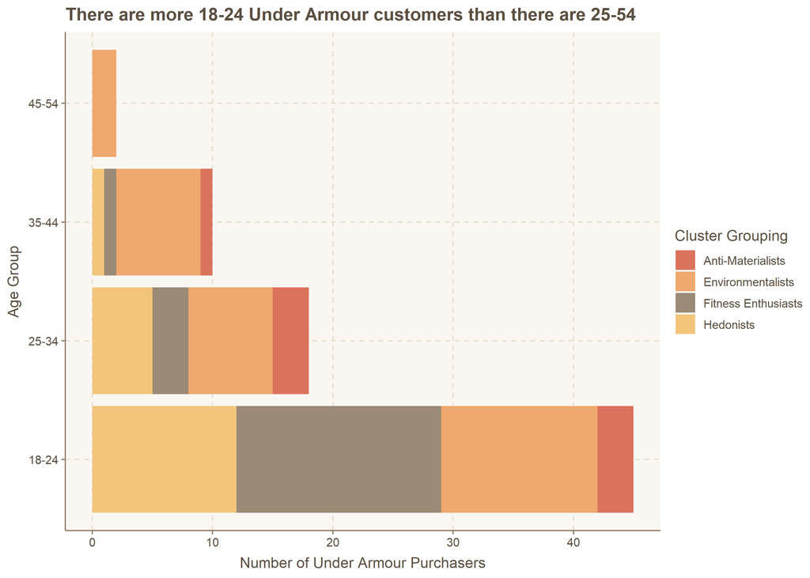

# Conclusion

While there may be hiccups along the way when entering unfamiliar territories, Under Armour is making the intelligent decision to poll consumers in the market we would like to enter. Without this data, we would be unable to tell how staggeringly important our younger audiences are to our brand, as well as the importance on sales. From this single survey, we know there is a very good chance our products will get into the hands of consumers better if we put sales on our products and market them to our younger audience. By doing this we should be able to bolster our other two most important marketing areas: Peer and Family opinion.